# Analysis_ConditionManipulation

Pauliina Vuorinen

04/10/2022-20/12/2023

# Introduction

In the study, participants’ autonomy in text selection was manipulated in an effort to influence their situational motivation. In the high-autonomy condition (*n* = 30), participants received a short story that they most wanted to read, whereas in the low-autonomy condition (*n* = 30) participants received a short story that they were not interested in.

## Hypothesis

H1: Participants in the high-autonomy condition experience more situational autonomous motivation compared to participants in the low-autonomy condition.

# Setup

```r
library(tidyverse)
library(dplyr)
library(psych)
```

Save working directory so that this script can be used elsewhere, if required. The working directory should be “~/Short-Story-Reading-Behaviour-Public/”.

The working directory is not changed with setwd() because this script is knit remotely in other scripts.

```r
if (exists("ExternalAnalysisFilePath")) {
    # ExternalAnalysisFilePath: ~/Short_Story_Reading_Behaviour_Public/
    mypath_SSRB <- ExternalAnalysisFilePath
} else if (grepl("Analysis", getwd())) {
    mypath_SSRB <- dirname(getwd())
} else if (grepl("Short_Story_Reading_Behaviour_Public", getwd())) {
    mypath_SSRB <- getwd()
} else {
    # get working directory manually
    mypath_SSRB <- paste0(
            dirname(getwd()),
            "/Short_Story_Reading_Behaviour_Public"
        )
}
```

## Load data

Load in the tracking_data dataset:

```r
tracking_data <-
    read.csv(
        paste0(
            mypath_SSRB,
            "/Data/wrangled_tracking_data.csv"
        ),
        header = TRUE,
        sep = ";",
        dec = ","
    )
tracking_data <- dplyr::select(tracking_data, -X, -X.1) # remove row numbers
```

Create a new dataframe from tracking_data that shows each participants’ condition:

```r
condition_data <- tracking_data %>%
    group_by(UserId, StoryId) %>%
    summarise(
        Condition = first(Condition)
    )
```

Re-name condition names to follow convention used in the manuscript:

```r
condition_data$Condition <- ifelse(
    condition_data$Condition == "AutonomousCondition",
    "HighAutonomyCondition",
    "LowAutonomyCondition"
)
```

We then load in questionnaire data:

```r
# IMI
IMI_scores <-
    read.csv(
        paste0(
            mypath_SSRB,
            "/Data/IMI_scores.csv"
        ),
        header = TRUE,
        sep = ";",
        dec = ","
    )
IMI_scores <- dplyr::select(IMI_scores, -X) # remove row numbers
# IMI-R
IMIR_scores <-
    read.csv(
        paste0(
            mypath_SSRB,
            "/Data/IMIR_scores.csv"
        ),
        header = TRUE,
        sep = ";",
        dec = ","
    )
IMIR_scores <- dplyr::select(IMIR_scores, -X) # remove row numbers
# Electronic experience
eexp_scores <-
    read.csv(
        paste0(
            mypath_SSRB,
            "/Data/eexp_scores.csv"
        ),
        header = TRUE,
        sep = ";",
        dec = ","
    )
eexp_scores <- dplyr::select(eexp_scores, -X) # remove row numbers
# demographic information
demographics_data <-
    read.csv(
        paste0(
            mypath_SSRB,
            "/Data/demographics_data.csv"
        ),
        header = TRUE,
        sep = ";",
        dec = ","
    )
demographics_data <- dplyr::select(demographics_data, -X) # remove row numbers
```

Merge the datasets together:

We then merge these dataframes together:

```r
# measure and IMI
condition_data <- merge(
    condition_data,
    IMI_scores,
    all.x = TRUE,
    by = "UserId"
)
# measure and IMI-R
condition_data <- merge(
    condition_data,
    IMIR_scores,
    all.x = TRUE,
    by = "UserId"
)
# measure and EEXP
condition_data <- merge(
    condition_data,
    eexp_scores,
    all.x = TRUE,
    by = "UserId"
)
# measure and demographic information
condition_data <- merge(
    condition_data,
    demographics_data,
    all.x = TRUE,
    by = "UserId"
)
```

## Change variable types

```r
str(condition_data)
```

```
## 'data.frame':    60 obs. of  14 variables:
##  $ UserId            : int  6 7 8 9 10 11 12 13 14 15 ...
##  $ StoryId           : int  7 2 8 6 9 5 8 2 8 5 ...
##  $ Condition         : chr  "LowAutonomyCondition" "LowAutonomyCondition" "HighAutonomyCondition" "LowAutonomyCondition" ...
##  $ SInterest         : int  38 8 31 29 42 35 37 37 24 46 ...
##  $ SCompetence       : int  31 15 28 27 29 29 22 30 25 31 ...
##  $ SAutonomy         : int  39 22 35 29 41 29 42 25 15 43 ...
##  $ CInterest         : int  57 48 41 53 55 50 54 47 53 44 ...
##  $ CCompetence       : int  32 23 31 30 29 30 30 30 36 34 ...
##  $ Eexp1LongformEFreq: int  2 3 3 2 5 3 3 2 6 3 ...
##  $ Eexp2DeviceRecFreq: int  4 8 6 4 6 7 11 7 10 10 ...
##  $ NumberOfDevices   : int  2 3 1 2 1 2 3 4 3 3 ...
##  $ Age               : int  22 21 21 20 22 22 20 24 20 21 ...
##  $ Gender            : chr  "Female" "Male" "Female" "Female" ...
##  $ NativeEnglish     : chr  "Yes" "No" "No" "No" ...
```

```r
source(
    paste0(
        mypath_SSRB,
        "/Functions/Functions_VariableTypeConversion.R"
    )
)

## turn columns into factors that should be factors
condition_data[, c(
    "UserId",
    "StoryId",
    "Condition"
)] <- convert.magic(
    condition_data[, c(
        "UserId",
        "StoryId",
        "Condition"
    )],
    "factor"
)
```

# Assess the impact of condition on autonomy

Participants were evenly divided in the two conditions (*n*<sub>High-Autonomy</sub> = 30, *n*<sub>Low-Autonomy</sub> = 30).

We expected that condition manipulation would result in differences in participants’ perceived autonomy. This situational autonomy was measured with SAutonomy from IMI.

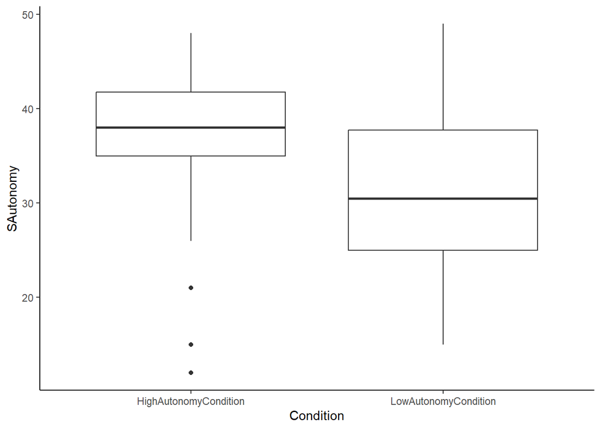

```r
ggplot(condition_data, aes(x = Condition, y = SAutonomy)) +
    geom_boxplot() +
    theme_classic()
```

The boxplot indicates that participants in the high-autonomy condition may have felt slightly more autonomous than participants in the low-autonomy condition.

We test this with a t-test:

```r
ConditionAutonomyTest <- t.test(
    condition_data$SAutonomy ~
        condition_data$Condition
)
ConditionAutonomyTest
```

```
##
##  Welch Two Sample t-test
##
## data:  condition_data$SAutonomy by condition_data$Condition
## t = 2.2026, df = 57.486, p-value = 0.03165
## alternative hypothesis: true difference in means between group HighAutonomyCondition and group LowAutonomyCondition is not equal to 0
## 95 percent confidence interval:
##  0.4702343 9.8630991
## sample estimates:
## mean in group HighAutonomyCondition  mean in group LowAutonomyCondition
##                            36.23333                            31.06667
```

Indeed, the t-test indicates that our condition manipulation was successful. Participants in the high-autonomy condition (*M* = 36.23, *SD* = 8.65) had significantly higher scores on the perceived autonomy subscale of IMI, compared to participants in the low-autonomy condition (*M* = 31.07, *SD* = 9.5), *t*(57.49) = 2.203, *p* = .032.

# Assess the impact of condition on situational motivation

We expected that the autonomy manipulation would have affect participants’ situational reading motivation during the study (H1 in manuscript). Participants in the high-autonomy condition should therefore have a higher situational interest score (measured via IMI, ‘SInterest’ reflects the extent of intrinsic motivation in IMI and thus it is used as a measure of situational motivation) than participants in the low-autonomy condition.

To test this hypothesis, we first visualise the relationship:

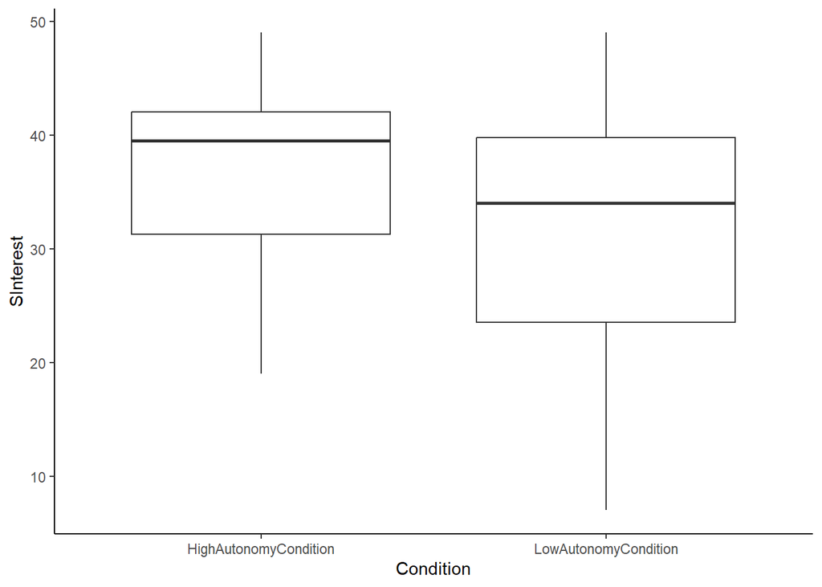

```r
ggplot(condition_data, aes(x = Condition, y = SInterest)) +
    geom_boxplot() +
    theme_classic()
```

The plot indicates that participants’ in the high-autonomy condition may have experienced higher situational motivation than participants in the low-autonomy condition.

We assess this with a t-test:

```r
ConditionMotivationTest <- t.test(
    condition_data$SInterest ~
        condition_data$Condition
)
ConditionMotivationTest
```

```
##
##  Welch Two Sample t-test
##
## data:  condition_data$SInterest by condition_data$Condition
## t = 2.2251, df = 49.662, p-value = 0.03065
## alternative hypothesis: true difference in means between group HighAutonomyCondition and group LowAutonomyCondition is not equal to 0
## 95 percent confidence interval:
##   0.5733176 11.2266824
## sample estimates:
## mean in group HighAutonomyCondition  mean in group LowAutonomyCondition
##                                37.4                                31.5
```

The t-test indicates that participants in the high-autonomy condition (*M* = 37.4, *SD* = 7.89) had significantly higher situational motivation than participants in the low-autonomy condition (*M* = 31.5, *SD* = 12.19), *t*(49.66) = 2.225, *p* = .031. Therefore, our H1 was supported as the condition manipulation had a significant effect on participants’ situational motivation.

Considering that the condition manipulation was effective, in analyses on reading behaviour ‘Condition’ is used as a measure of Situational Autonomous Motivation (considering that it is significantly connected to SInterest and SAutonomy).

# Connection to other questionnaire variables

We then assess whether condition is connected to any other questionnaire variables. This is to make sure that the participants in the two conditions do not happen to have, for example, different demographic attributes or contextual motivation scores.

## Situational competence

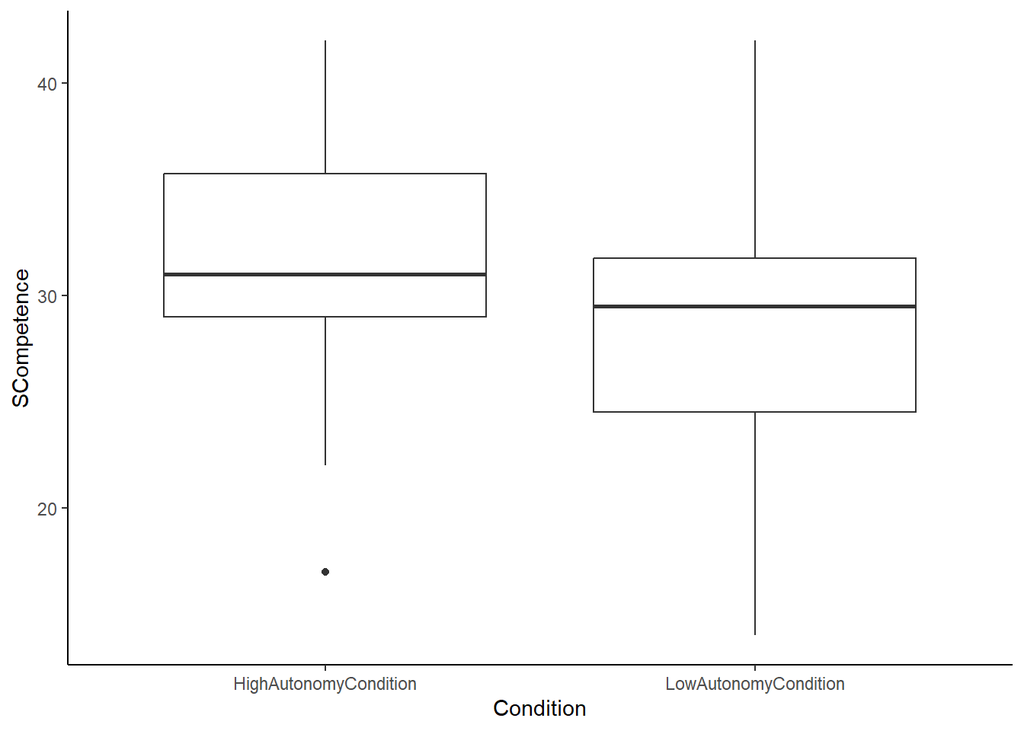

```r
ggplot(condition_data, aes(x = Condition, y = SCompetence)) +
    geom_boxplot() +
    theme_classic()
```

```r
# connection to SCompetence
ConditionSituationalCompetenceTest <- t.test(
    condition_data$SCompetence ~
        condition_data$Condition
)
ConditionSituationalCompetenceTest
```

```
##
##  Welch Two Sample t-test
##
## data:  condition_data$SCompetence by condition_data$Condition
## t = 1.7289, df = 56.205, p-value = 0.08931
## alternative hypothesis: true difference in means between group HighAutonomyCondition and group LowAutonomyCondition is not equal to 0
## 95 percent confidence interval:
##  -0.4492458  6.1159124
## sample estimates:
## mean in group HighAutonomyCondition  mean in group LowAutonomyCondition
##                            31.46667                            28.63333
```

The participants do not significantly differ in their situational competence scores, *t*(56.21) = 1.729, *p* = .089. Therefore, the condition manipulation did not influence participants’ feelings of whether the story was difficult to read or not.

## Contextual motivation

Interest scores:

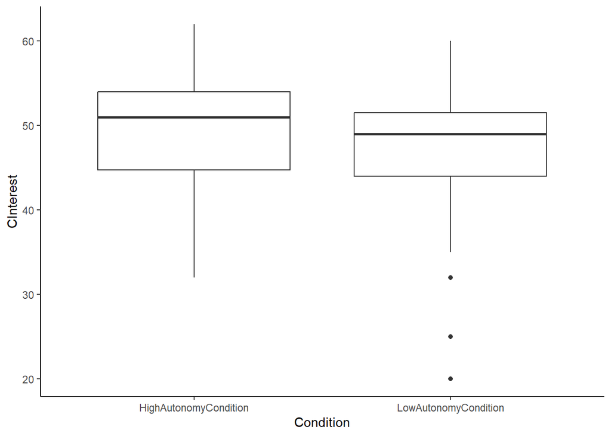

```r
ggplot(condition_data, aes(x = Condition, y = CInterest)) +
    geom_boxplot() +
    theme_classic()
```

```r
# connection to CInterest
ConditionContextualMotivationTest <- t.test(
    condition_data$CInterest ~
        condition_data$Condition
)
ConditionContextualMotivationTest
```

```
##
##  Welch Two Sample t-test
##
## data:  condition_data$CInterest by condition_data$Condition
## t = 1.1807, df = 55.145, p-value = 0.2428
## alternative hypothesis: true difference in means between group HighAutonomyCondition and group LowAutonomyCondition is not equal to 0
## 95 percent confidence interval:
##  -1.836048  7.102714
## sample estimates:
## mean in group HighAutonomyCondition  mean in group LowAutonomyCondition
##                            49.46667                            46.83333
```

The participants do not significantly differ in their contextual motivation scores, *t*(55.14) = 1.181, *p* = .243. Therefore, the participants in the two conditions had comparable levels of contextual motivation for recreational reading.

Competence scores:

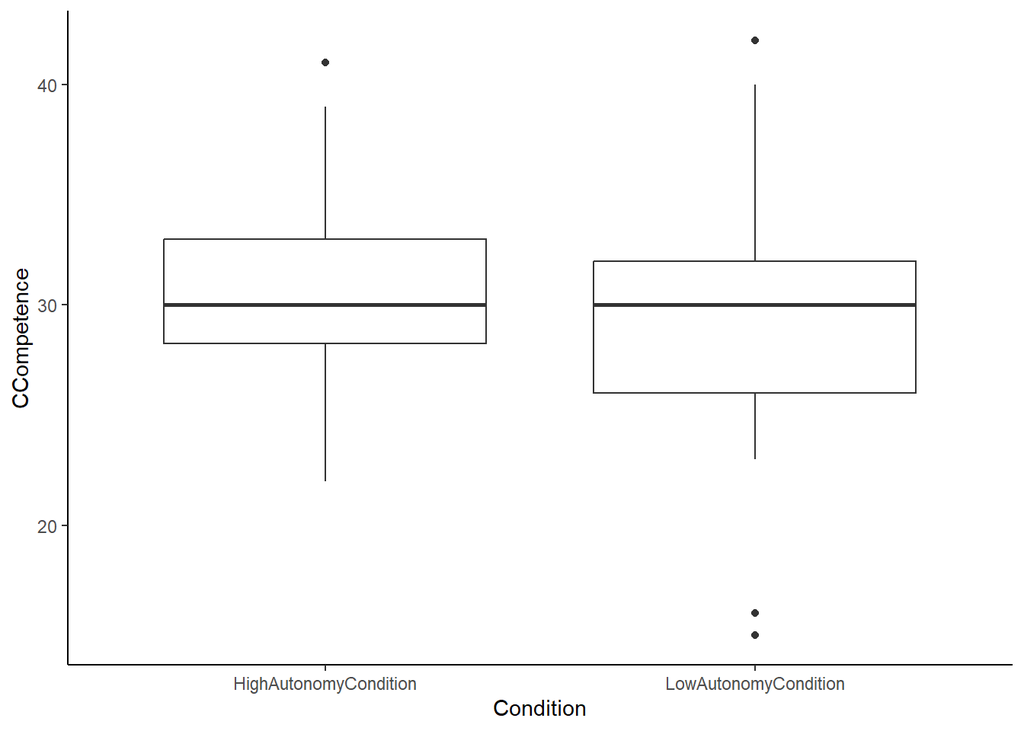

```r
ggplot(condition_data, aes(x = Condition, y = CCompetence)) +
    geom_boxplot() +
    theme_classic()
```

```r
# connection to CCompetence
ConditionContextualCompetenceTest <- t.test(
    condition_data$CCompetence ~
        condition_data$Condition
)
ConditionContextualCompetenceTest
```

```
##
##  Welch Two Sample t-test
##
## data:  condition_data$CCompetence by condition_data$Condition
## t = 1.446, df = 55.676, p-value = 0.1538
## alternative hypothesis: true difference in means between group HighAutonomyCondition and group LowAutonomyCondition is not equal to 0
## 95 percent confidence interval:
##  -0.7710819  4.7710819
## sample estimates:
## mean in group HighAutonomyCondition  mean in group LowAutonomyCondition
##                            30.83333                            28.83333
```

Similarly, the participants do not significantly differ in their contextual motivation scores, *t*(55.68) = 1.446, *p* = .154. Therefore, the participants in the two conditions had comparable levels of self-reported reading ability.

## Electronic reading experience

Task-relevant text types:

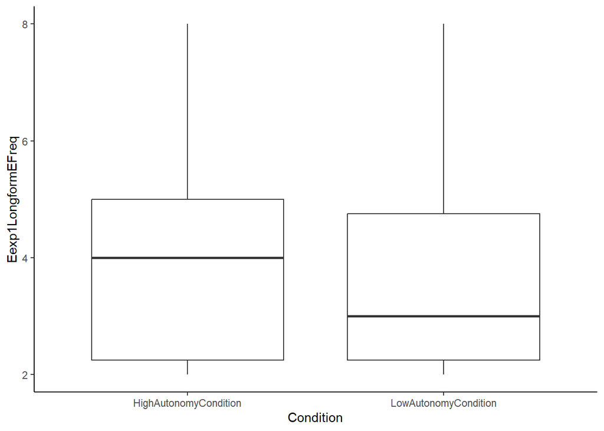

```r
ggplot(condition_data, aes(x = Condition, y = Eexp1LongformEFreq)) +
    geom_boxplot() +
    theme_classic()
```

```r
# connection to task-relevant text types
ConditionTextTypesTest <- t.test(
    condition_data$Eexp1LongformEFreq ~
        condition_data$Condition
)
ConditionTextTypesTest
```

```
##
##  Welch Two Sample t-test
##
## data:  condition_data$Eexp1LongformEFreq by condition_data$Condition
## t = 0.6989, df = 57.693, p-value = 0.4874
## alternative hypothesis: true difference in means between group HighAutonomyCondition and group LowAutonomyCondition is not equal to 0
## 95 percent confidence interval:
##  -0.5593284  1.1593284
## sample estimates:
## mean in group HighAutonomyCondition  mean in group LowAutonomyCondition
##                                 4.0                                 3.7
```

The participants do not significantly differ in their frequency of reading task-relevant text types electronically, *t*(57.69) = 0.699, *p* = .487.

Task-relevant devices:

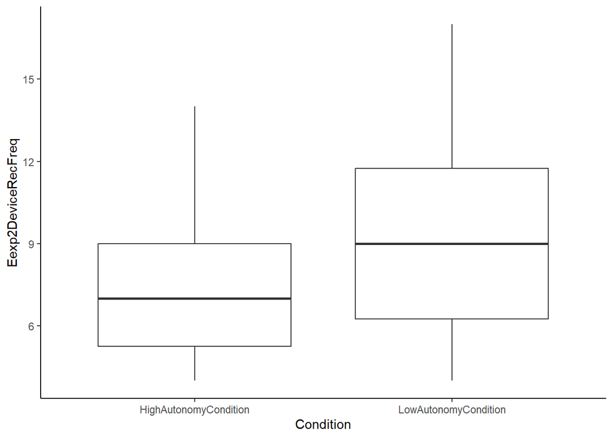

```r
ggplot(condition_data, aes(x = Condition, y = Eexp2DeviceRecFreq)) +
    geom_boxplot() +
    theme_classic()
```

```r
# connection to task-relevant devices
ConditionDevicesTest <- t.test(
    condition_data$Eexp2DeviceRecFreq ~
        condition_data$Condition
)
ConditionDevicesTest
```

```
##
##  Welch Two Sample t-test
##
## data:  condition_data$Eexp2DeviceRecFreq by condition_data$Condition
## t = -2.4847, df = 54.325, p-value = 0.01608
## alternative hypothesis: true difference in means between group HighAutonomyCondition and group LowAutonomyCondition is not equal to 0
## 95 percent confidence interval:
##  -3.7339875 -0.3993458
## sample estimates:
## mean in group HighAutonomyCondition  mean in group LowAutonomyCondition
##                            7.333333                            9.400000
```

Although the participants have comparable levels of electronic experience of reading task-relevant text types, the participants in the two conditions significantly differ in how frequently they use task-relevant digital devices for recreational reading purposes, *t*(54.33) = -2.485, *p* = .016. Indeed, participants in the low-autonomy condition (*M* = 9.4, *SD* = 3.62) reported using task-relevant digital devices for reading more often than participants in the high-autonomy condition (*M* = 7.33, *SD* = 2.77).

## Demographic information

Age:

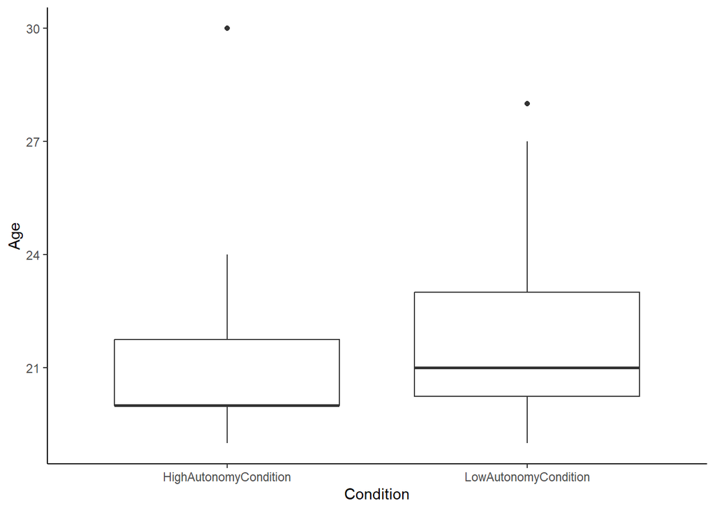

```r
ggplot(condition_data, aes(x = Condition, y = Age)) +
    geom_boxplot() +
    theme_classic()
```

Gender:

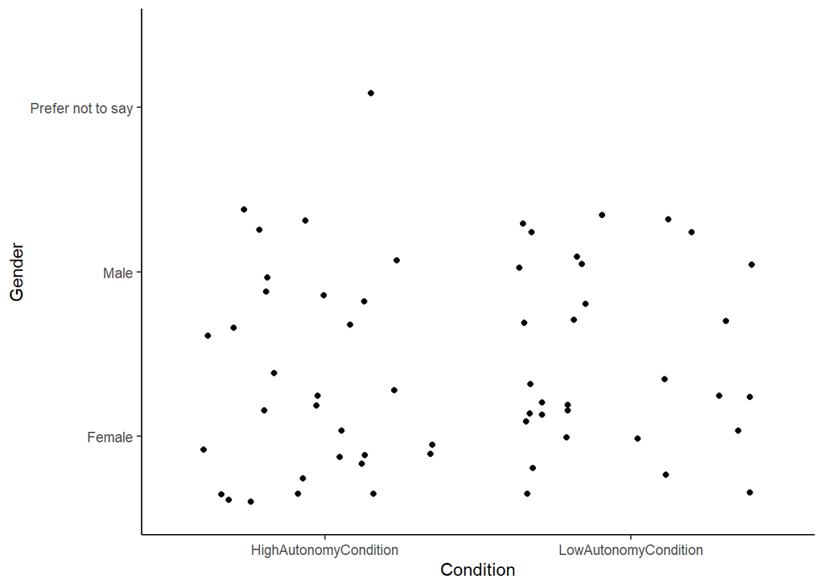

```r
ggplot(condition_data, aes(x = Condition, y = Gender)) +
    geom_jitter() +
    theme_classic()
```

Whether each participant is a native English speaker or not:

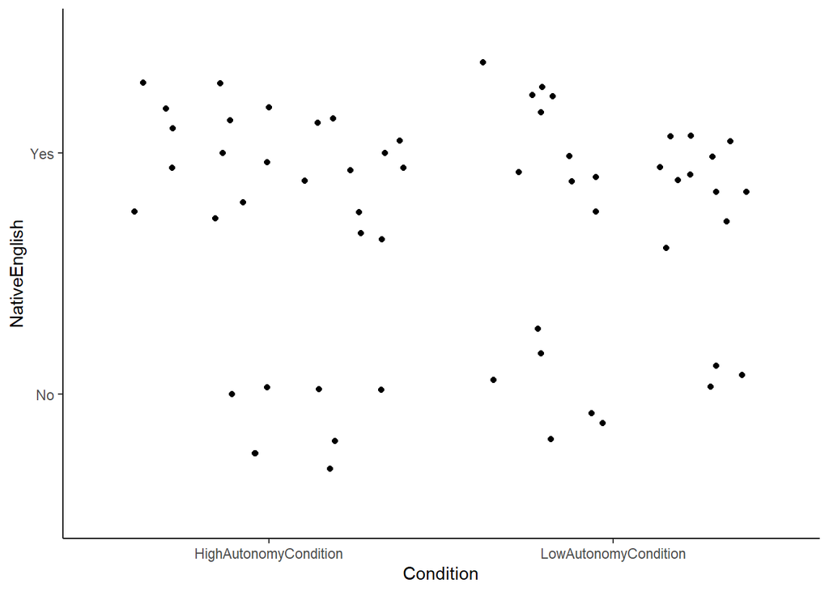

```r
ggplot(condition_data, aes(x = Condition, y = NativeEnglish)) +
    geom_jitter() +
    theme_classic()
```